# Practice Data Analysis Larval Traits

Here we will practice some analyses to use on the larval fish morphology data.

We’re using a R Markdown Document. Here we can type freely, within chunks (grey) to type normal text as notes we have to start the line with a hash (#)

```r
#load packages or apps
library(tidyverse) #if you don't have it installed, you'll have to do that first by install.packages("tidyverse")
```

Bring in data stored as csvs

```r
photos <- read.csv("/Users/zoekitchel/Documents/grad school/Rutgers/mentoring/Justin/DataSheetPhotos_Practice.csv") #You'll have to change this path to match your machine, also note that for Windows, you will need to use backslashes instead of forward slashes (\ versus /)
measurements <- read.csv("/Users/zoekitchel/Documents/grad school/Rutgers/mentoring/Justin/Measurements_practice.csv")

icthy_data <- read.csv("/Users/zoekitchel/Documents/grad school/Rutgers/mentoring/Justin/icthy_data_Practice.csv")
```

Now we’ve loaded in three CSVs to data frames. You’ll see them in your Environment in the top right.

Now, let’s take a look at these!

```r
View(photos) #let's view it like a spreadsheet above
summary(photos) #overall summary and statistics
```

```
      Code                             Spp         Tow.Date      Tow_ID          Tow_num   Picture.Date
 Min.   :600000   Micropogonias undulatus:42   12/3/17 : 5   Min.   :  1.00   Min.   :1   6/15/21: 2
 1st Qu.:625016   Paralichthys dentatus  :44   9/11/17 : 5   1st Qu.: 11.25   1st Qu.:1   6/16/21: 2
 Median :700020                                9/12/17 : 5   Median : 61.50   Median :1   6/17/21: 2
 Mean   :724434                                11/23/17: 4   Mean   : 61.26   Mean   :1   6/18/21: 2
 3rd Qu.:800021                                11/24/17: 4   3rd Qu.:111.00   3rd Qu.:1   6/19/21: 2
 Max.   :900000                                12/4/17 : 4   Max.   :122.00   Max.   :1   6/20/21: 2
                                               (Other) :59                                (Other):74
  Fish.Number  Notes
 Min.   :1    Mode:logical
 1st Qu.:1    NA's:86
 Median :1
 Mean   :1
 3rd Qu.:1
 Max.   :1
```

```r
str(photos) #structure, are the columns in the right format?
```

```
'data.frame':   86 obs. of  8 variables:
 $ Code        : int  800011 700000 800013 700001 800015 700002 800016 700003 800017 700004 ...
 $ Spp         : Factor w/ 2 levels "Micropogonias undulatus",..: 1 2 1 2 1 2 1 2 1 2 ...
 $ Tow.Date    : Factor w/ 43 levels "11/23/17","11/24/17",..: 24 15 25 16 26 17 27 32 28 34 ...
 $ Tow_ID      : int  1 1 2 2 3 3 4 4 5 5 ...
 $ Tow_num     : int  1 1 1 1 1 1 1 1 1 1 ...
 $ Picture.Date: Factor w/ 43 levels "6/15/21","6/16/21",..: 1 20 2 21 3 22 4 23 5 24 ...
 $ Fish.Number : int  1 1 1 1 1 1 1 1 1 1 ...
 $ Notes       : logi  NA NA NA NA NA NA ...
```

```r
#check this out for all of the data frames
#numerical columns should be <int> or <dbl>
```

It appears that photos has some extra useless columns, let’s delete those

```r
View(photos)
#keep columns 1:8
photos_reduced <- photos[,1:7] #this tells us to make a new data frame extracting all rows from columns 1:8 (column = after comma, row = before comma]) in photos data frame
```

We also don’t want the data from icthy_data that’s not for our focal species

```r
summary(icthy_data$Species)
```

```
americanus     dentatus     fimbria   undulatus
         44          23          21          42
```

```r
icthy_data_reduced <- icthy_data %>% #first, access icthy_data
  filter(Species == "dentatus" | Species == "undulatus") #then, filter out only rows where Species is eitheer dentatus or undulatus

summary(icthy_data_reduced$Species) #success!
```

```
americanus     dentatus     fimbria   undulatus
          0          23           0          42
```

We now need to merge these data frames together, which columns are the same across data frames?

```r
colnames(photos_reduced)
```

```
[1] "Code"         "Spp"          "Tow.Date"     "Tow_ID"       "Tow_num"      "Picture.Date"
[7] "Fish.Number"
```

```r
colnames(measurements)
```

```
[1] "Code" "TL"   "SL"   "CPD"  "CFA"  "BA"   "PA"   "BW"   "BDP"
```

```r
colnames(icthy_data_reduced)
```

```
[1] "Tow"         "Genus"       "Species"     "Survey"      "Preserve"    "Number"      "Location"
[8] "Temperature"
```

```r
#it can also be helpful to look at the first few rows
head(photos_reduced)
```

|  | Code | Spp | Tow.Date | Tow_ID | Tow_num | Picture.Date | Fish.Number |
| --- | --- | --- | --- | --- | --- | --- | --- |
| 1 | 800011 | Micropogonias undulatus | 9/11/17 | 1 | 1 | 6/15/21 | 1 |
| 2 | 700000 | Paralichthys dentatus | 12/3/17 | 1 | 1 | 7/12/21 | 1 |
| 3 | 800013 | Micropogonias undulatus | 9/12/17 | 2 | 1 | 6/16/21 | 1 |
| 4 | 700001 | Paralichthys dentatus | 12/4/17 | 2 | 1 | 7/13/21 | 1 |
| 5 | 800015 | Micropogonias undulatus | 9/13/17 | 3 | 1 | 6/17/21 | 1 |
| 6 | 700002 | Paralichthys dentatus | 12/5/17 | 3 | 1 | 7/14/21 | 1 |

```r
head(measurements)
```

|  | Code | TL | SL | CPD | CFA | BA | PA | BW | BDP |
| --- | --- | --- | --- | --- | --- | --- | --- | --- | --- |
| 1 | 800011 | 22.9 | 20.9 | 2.9 | 4.4 | 62.7 | 42.7 | 1.1 | 4.3 |
| 2 | 800013 | 21.2 | 19.2 | 1.9 | 4.4 | 57.6 | 40.6 | 1.2 | 3.3 |
| 3 | 800015 | 20.4 | 19.4 | 1.1 | 4.8 | 58.2 | 39.2 | 1.2 | 2.5 |
| 4 | 800016 | 20.9 | 19.9 | 2.8 | 4.2 | 59.7 | 44.7 | 1.4 | 3.8 |
| 5 | 800017 | 21.0 | 19.0 | 1.2 | 4.8 | 57.0 | 40.0 | 1.4 | 2.6 |
| 6 | 800018 | 21.9 | 20.9 | 3.7 | 3.9 | 62.7 | 44.7 | 1.5 | 2.1 |

```r
head(icthy_data_reduced)
```

|  | Tow | Genus | Species | Survey | Preserve | Number | Location | Temperature |
| --- | --- | --- | --- | --- | --- | --- | --- | --- |
| 1 | 1 | Micropogonias | undulatus | ICHPLAN | ETOH | 4 | LSHCB | 20.7 |
| 2 | 1 | Paralichthys | dentatus | ICHPLAN | ETOH | 70 | LSHCB | 4.7 |
| 3 | 2 | Micropogonias | undulatus | ICHPLAN | ETOH | 8 | LSHCB | 21.5 |
| 4 | 2 | Paralichthys | dentatus | ICHPLAN | ETOH | 86 | LSHCB | 6.4 |
| 5 | 3 | Micropogonias | undulatus | ICHPLAN | ETOH | 10 | LSHCB | 21.8 |
| 6 | 3 | Paralichthys | dentatus | ICHPLAN | ETOH | 89 | LSHCB | 4.7 |

```r
#check that all date columns are correctly formatted
photos_reduced$Tow.Date <- mdy(photos_reduced$Tow.Date) #tells R to interpret this column as a date in month, day, year format

#note that $ calls a specific column. RStudio is awesome, because once you start typing a column name it will give you options in a drop down menu

head(photos_reduced) #note it now says <date> under Tow.Date
```

|  | Code | Spp | Tow.Date | Tow_ID | Tow_num | Picture.Date | Fish.Number |
| --- | --- | --- | --- | --- | --- | --- | --- |
| 1 | 800011 | Micropogonias undulatus | 2017-09-11 | 1 | 1 | 6/15/21 | 1 |
| 2 | 700000 | Paralichthys dentatus | 2017-12-03 | 1 | 1 | 7/12/21 | 1 |
| 3 | 800013 | Micropogonias undulatus | 2017-09-12 | 2 | 1 | 6/16/21 | 1 |
| 4 | 700001 | Paralichthys dentatus | 2017-12-04 | 2 | 1 | 7/13/21 | 1 |
| 5 | 800015 | Micropogonias undulatus | 2017-09-13 | 3 | 1 | 6/17/21 | 1 |
| 6 | 700002 | Paralichthys dentatus | 2017-12-05 | 3 | 1 | 7/14/21 | 1 |

```r
#this needs to be done for all columns
```

Match Spp to Genus Spp -In photos_reduced, species is under spp, but in icthy data species is under genus and species, we have to match them

```r
#make new Species column in photos_reduced data frame
photos_reduced$Species <- as.factor(word(photos_reduced$Spp,2,2, sep = " ")) #pull out species
#want to know how this is working?
?word
#make new Genus column in photos_reduced data frame
photos_reduced$Genus <- as.factor(word(photos_reduced$Spp,1,1, sep = " "))
```

Now, I’ve noticed that we use Tow_ID in photo data frame, but Tow in icthy_data_reduced data frame, let’s match

```r
icthy_data_reduced$Tow_ID <- icthy_data_reduced$Tow
```

Time to merge!

```r
icthy_data_photos <- inner_join(photos_reduced, icthy_data_reduced, by = c("Tow_ID", "Species", "Genus")) #first merge

full_merge_icthyoplankton <- inner_join(icthy_data_photos, measurements, by = c("Code"))

View(full_merge_icthyoplankton)
nrow(full_merge_icthyoplankton)
```

```
[1] 64
```

#Now it’s time for analyses A good way to start each analysis is to ask a specific question.

1. How does sample # change by date and location for each species?

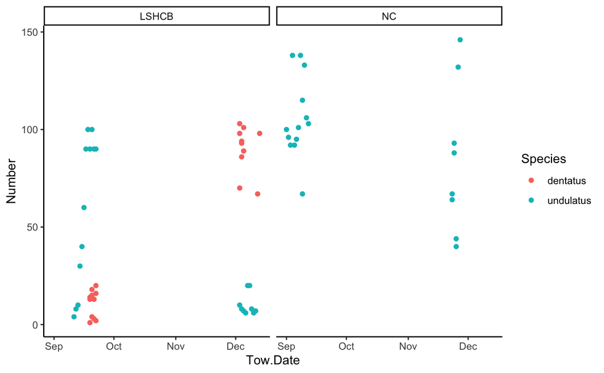

```r
ggplot(data = full_merge_icthyoplankton) +
  geom_point(aes(x = Tow.Date, y = Number, color = Species)) +
  facet_wrap(~Location) +
  theme_classic()
```

2. Does standard length vary by date? Is this pattern different for different locations and species?

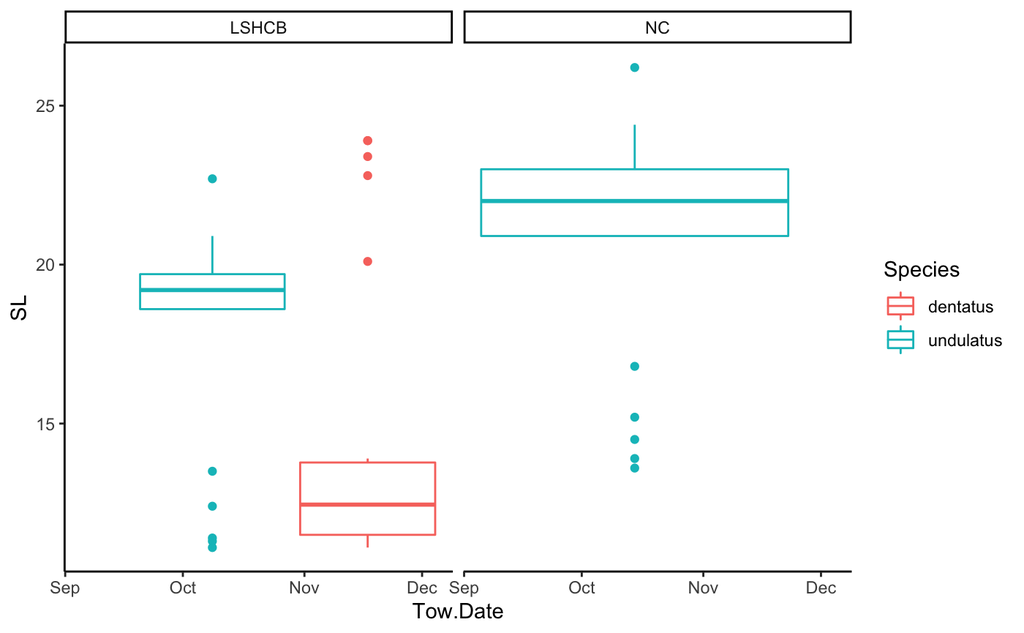

3. Now, we can ask a ton of different questions

Variables to include: - Species - Location - Morphological traits - Number of fish - Temperature - Date